# HW3

Artur Sak (sak2)

September 20, 2016

## Q1 (5 pts)

Given a function below,

```r
myfunc <- function(z) return(c(z,z^2, z^3%/%2))
```

1. Examine the following code, and briefly explain what it is doing.

```r
y = 2:8
matrix(myfunc(y),ncol=3)
```

```
##      [,1] [,2] [,3]
## [1,]    2    4    4
## [2,]    3    9   13
## [3,]    4   16   32
## [4,]    5   25   62
## [5,]    6   36  108
## [6,]    7   49  171
## [7,]    8   64  256
```

2. Simplify the code in (1) using one of the “apply” functions and save the result as m.

```r
m = t(sapply(y, myfunc))
print(m)
```

```
##      [,1] [,2] [,3]
## [1,]    2    4    4
## [2,]    3    9   13
## [3,]    4   16   32
## [4,]    5   25   62
## [5,]    6   36  108
## [6,]    7   49  171
## [7,]    8   64  256
```

3. Find the row product of m.

```r
print(apply(m,1,prod))
```

```
## [1]     32    351   2048   7750  23328  58653 131072
```

4. Find the column sum of m in two ways.

```r
print(apply(m,2,sum))
```

```
## [1]  35 203 646
```

```r
print(colSums(m))
```

```
## [1]  35 203 646
```

5. Could you divide all the values by 2 in two ways?

```r
print(apply(m,2,function(x) x/2))
```

```
##      [,1] [,2]  [,3]
## [1,]  1.0  2.0   2.0
## [2,]  1.5  4.5   6.5
## [3,]  2.0  8.0  16.0
## [4,]  2.5 12.5  31.0
## [5,]  3.0 18.0  54.0
## [6,]  3.5 24.5  85.5
## [7,]  4.0 32.0 128.0
```

```r
print(m/2)
```

```
##      [,1] [,2]  [,3]
## [1,]  1.0  2.0   2.0
## [2,]  1.5  4.5   6.5
## [3,]  2.0  8.0  16.0
## [4,]  2.5 12.5  31.0
## [5,]  3.0 18.0  54.0
## [6,]  3.5 24.5  85.5
## [7,]  4.0 32.0 128.0
```

Yes.

## Q2 (8 pts)

Create a list with 2 elements as follows:

```r
l <- list(a = 1:10, b = 11:20)
```

1. What is the product of the values in each element?

```r
print(lapply(l, prod))
```

```
## $a
## [1] 3628800
##
## $b
## [1] 670442572800
```

2. What is the (sample) variance of the values in each element?

```r
print(lapply(l, var))
```

```
## $a
## [1] 9.166667
##
## $b
## [1] 9.166667
```

3. What type of object is returned if you use lapply? sapply? Show your R code that finds these answers.

```r
class(lapply(l,var))
```

```
## [1] "list"
```

```r
class(sapply(l,var))
```

```
## [1] "numeric"
```

Now create the following list:

```r
l.2 <- list(c = c(21:30), d = c(31:40))
```

4. What is the sum of the corresponding elements of l and l.2, using one function call?

```r
print(mapply(sum, l$a,l$b,l.2$c,l.2$d))
```

```
##  [1]  64  68  72  76  80  84  88  92  96 100
```

5. Take the log of each element in the list l:

```r
print(lapply(l, log))
```

```
## $a
##  [1] 0.0000000 0.6931472 1.0986123 1.3862944 1.6094379 1.7917595 1.9459101
##  [8] 2.0794415 2.1972246 2.3025851
##
## $b
##  [1] 2.397895 2.484907 2.564949 2.639057 2.708050 2.772589 2.833213
##  [8] 2.890372 2.944439 2.995732
```

6. First change l and l.2 into matrices, make each element in the list as column,

```r
l = sapply(l, cbind)
l.2 = do.call(cbind,l.2)
```

Then, form a list named mylist using l,l.2 and m (from Q1) (in this order).

```r
mylist = list(l, l.2, m)
print(mylist)
```

```
## [[1]]
##        a  b
##  [1,]  1 11
##  [2,]  2 12
##  [3,]  3 13
##  [4,]  4 14
##  [5,]  5 15
##  [6,]  6 16
##  [7,]  7 17
##  [8,]  8 18
##  [9,]  9 19
## [10,] 10 20
##
## [[2]]
##        c  d
```

[output cut: 20 more lines]

Then, select the first column of each elements in mylist in one function call (hint ‘[’ is the select operator).

```r
print(lapply(mylist, '[', ,1))
```

```
## [[1]]
##  [1]  1  2  3  4  5  6  7  8  9 10
##
## [[2]]
##  [1] 21 22 23 24 25 26 27 28 29 30
##
## [[3]]
## [1] 2 3 4 5 6 7 8
```

## Q3 (3 pts)

Let’s load our friend family data again.

```r
load(url("http://courseweb.lis.illinois.edu/~jguo24/family.rda"))
```

1. Find the mean bmi by gender in one function call.

```r
print(tapply(family$bmi, family$gender, mean))
```

```
##        m        f
## 25.73898 23.02564
```

2. Could you get a vector of what the type of variables the dataset is made of？

```r
print(sapply(family, class))
```

```
## firstName    gender       age    height    weight       bmi    overWt
##  "factor"  "factor" "integer" "numeric" "integer" "numeric" "logical"
```

Yes.

3. Could you sort the firstName in height descending order?

```r
print(family[order(-family$height), c("firstName","height")])
```

```
##    firstName height
## 3        Joe     73
## 10       Tom     71
## 1        Tom     70
## 6        Liz     68
## 7        Jon     68
## 9        Tim     68
## 4        Bob     67
## 11       Ann     67
## 12       Dan     66
## 13       Art     66
## 8        Sal     65
## 2        May     64
## 5        Sue     64
## 14       Zoe     62
```

Yes.

## Q4 (2 pts)

There is a famous dataset in R called “iris.” It should already be loaded in R for you. If you type in ?iris you can see some documentation. Familiarize yourself with this dataset.

```r
?iris
```

1. Find the mean petal length by species.

```r
print(tapply(iris$Petal.Length, iris$Species, mean))
```

```
##     setosa versicolor  virginica
##      1.462      4.260      5.552
```

2. Now obtain the sum of the first 4 variables, by species, but using only one function call.

```r
print(aggregate(.~Species, iris, sum))
```

```
##      Species Sepal.Length Sepal.Width Petal.Length Petal.Width
## 1     setosa        250.3       171.4         73.1        12.3
## 2 versicolor        296.8       138.5        213.0        66.3
## 3  virginica        329.4       148.7        277.6       101.3
```

## Q5 (2 pts)

Below are two statements, their results have different structure,

```r
lapply(1:4, function(x) x^3)
sapply(1:4, function(x) x^3)
```

Could you change one of them to make the two statements return the same results (type of object)?

Yes either pass in ‘simplify=FALSE’ as a parameter to sapply() or wrap the lapply() in unlist().

```r
print(unlist(lapply(1:4, function(x) x^3)))
```

```
## [1]  1  8 27 64
```

```r
print(sapply(1:4, function(x) x^3))
```

```
## [1]  1  8 27 64
```

```r
print(sapply(1:4, function(x) x^3, simplify=F))
```

```
## [[1]]
## [1] 1
##
## [[2]]
## [1] 8
##
## [[3]]
## [1] 27
##
## [[4]]
## [1] 64
```

## Q6. (5 pts)

Using the family data, fit a linear regression model to predict weight from height. Place your code and output (the model) below.

```r
model = lm(family$weight~family$height)
print(summary(model))
```

```
##
## Call:
## lm(formula = family$weight ~ family$height)
##
## Residuals:
##     Min      1Q  Median      3Q     Max
## -27.554  -9.689  -0.055  11.944  23.214
##
## Coefficients:
##               Estimate Std. Error t value Pr(>|t|)
## (Intercept)   -455.666    107.029  -4.257  0.00111 **
## family$height    9.154      1.594   5.741 9.29e-05 ***
## ---
## Signif. codes:  0 '***' 0.001 '**' 0.01 '*' 0.05 '.' 0.1 ' ' 1
##
## Residual standard error: 16.94 on 12 degrees of freedom
## Multiple R-squared:  0.7331, Adjusted R-squared:  0.7109
## F-statistic: 32.96 on 1 and 12 DF,  p-value: 9.287e-05
```

How do you interpret this model?

- If height increases by 1 inch, weight is expected to increase by $\approx$ 9.15lbs.
- The predictive model appears to be a good fit with p-values on the coefficients as well as the overall F-statistic being $<$ 0.05
- The variables appear to have a strong positive correlation ($\approx$ 86%).

Create a scatterplot of height vs weight. Add the linear regression line you found above.

There appears to be a strong positive relationship between height and weight in the family data provided.

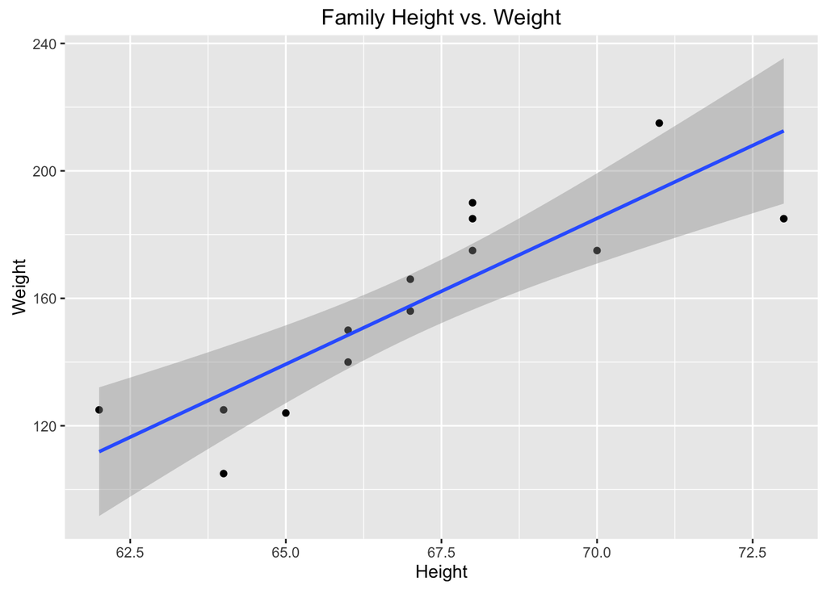

```r
library(ggplot2)
ggplot(family, aes(x=height, y=weight)) + geom_point(shape=19) + geom_smooth(method=lm) + ggtitle("Family Height vs. Weight") + labs(x="Height", y="Weight")
```